# Лабораторная работа №15

Настройка сетевого журналирования

Жукова Арина Александровна

1132239120@rudn.ru

Российский университет дружбы народов

2025-12-15

# Информация

## Докладчик

- Жукова Арина Александровна
- Направление прикладная информатика
- Студентка 3 курса
- Группа НПИбд-01-23
- Российский университет дружбы народов им. П. Лумумбы
- 1132239120@rudn.ru

# Вводная часть

## Актуальность

- Централизованное журналирование — важная часть администрирования сетей
- Упрощает мониторинг и анализ системных событий
- Повышает безопасность и целостность лог-сообщений
- Упрощает управление дисковым пространством

## Цели и задачи

**Цель:** Получение навыков по работе с журналами системных событий

**Задачи:**

1. Настроить сервер сетевого журналирования
2. Настроить клиент для передачи сообщений
3. Освоить методы просмотра журналов
4. Автоматизировать настройку через Vagrant

## Материалы и методы

- Операционная система: Rocky Linux 10
- Служба журналирования: rsyslog
- Межсетевой экран: firewalld
- Утилиты просмотра: tail, multitail
- Виртуализация: Vagrant с VirtualBox

# Настройка сервера сетевого журнала

## Создание конфигурационного файла

```bash
cd /etc/rsyslog.d
touch netlog-server.conf
```

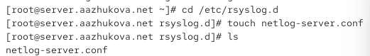

## Настройка приёма сообщений по TCP

```bash
# netlog-server.conf
$ModLoad imtcp
$InputTCPServerRun 514
```

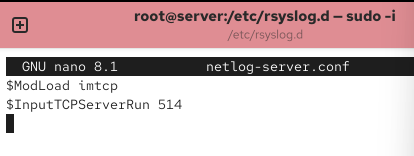

## Запуск службы и проверка портов

```bash
systemctl restart rsyslog
lsof | grep TCP
```

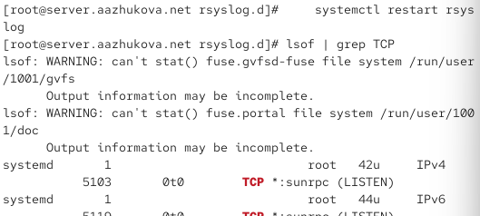

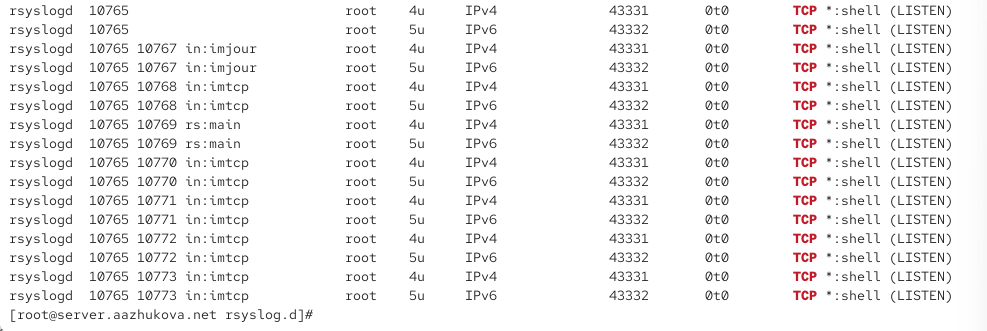

## Настройка межсетевого экрана

```bash
firewall-cmd --add-port=514/tcp
firewall-cmd --add-port=514/tcp --permanent
```

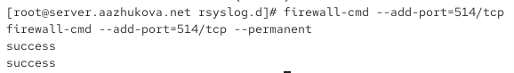

# Настройка клиента сетевого журнала

## Создание конфигурационного файла клиента

```bash
cd /etc/rsyslog.d
touch netlog-client.conf
```

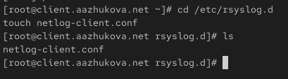

## Настройка перенаправления логов на сервер

```bash
# netlog-client.conf
*.* @@server.aazhukova.net:514
```

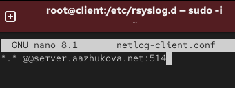

## Перезапуск службы rsyslog на клиенте

```bash
systemctl restart rsyslog
```

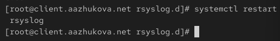

# Просмотр журналов

## Просмотр логов в реальном времени

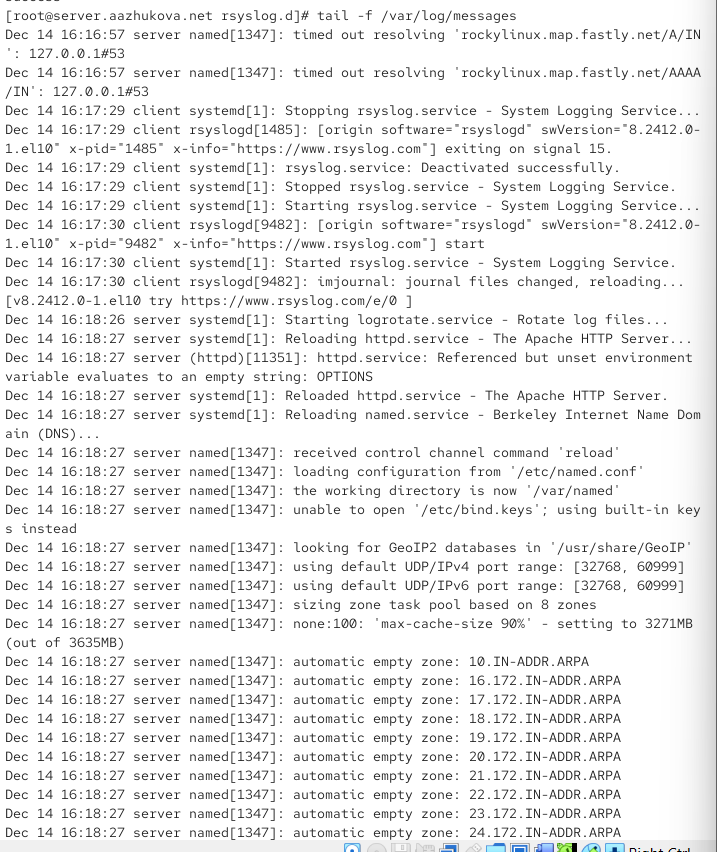

```bash
tail -f /var/log/messages
```

- Запись содержит имя хоста-источника (client)
- Сообщение успешно передано и сохранено на сервере
- Формат временных меток сохранён

```bash
gnome-system-monitor
```

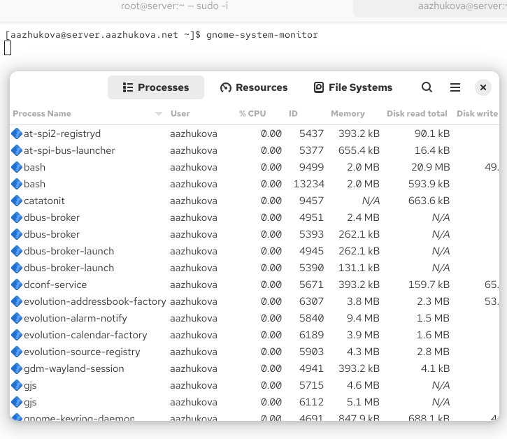

## Установка альтернативных просмотрщиков

Попытка установки lnav

```bash
dnf -y install lnav
```

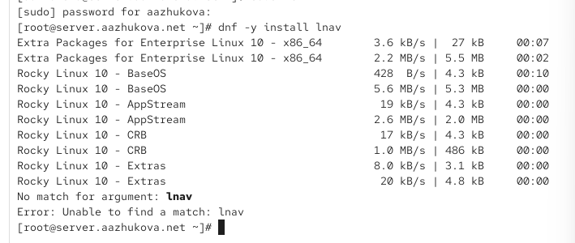

## Установка multitail

Установка multitail вместо lnav

```bash
dnf -y install multitail
```

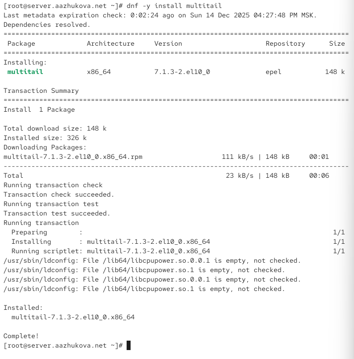

## Просмотр логов через multitail

```bash
multitail /var/log/messages
```

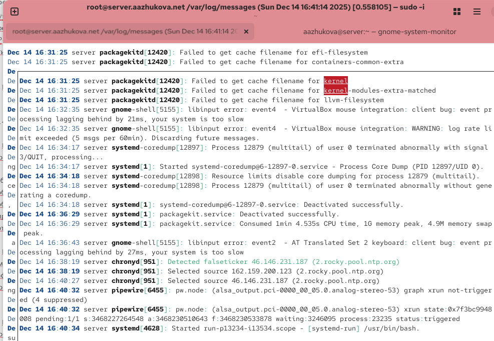

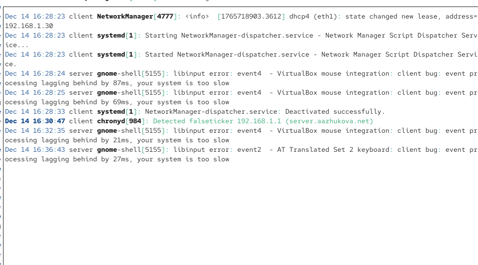

# Автоматизация настройки

## Подготовка файлов конфигурации

```bash
cd /vagrant/provision/server
mkdir -p /vagrant/provision/server/netlog/etc/rsyslog.d
cp -R /etc/rsyslog.d/netlog-server.conf \
  /vagrant/provision/server/netlog/etc/rsyslog.d
```

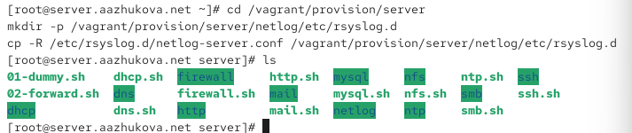

## Создание скрипта настройки для сервера

```bash
cd /vagrant/provision/server
touch netlog.sh
chmod +x netlog.sh
```

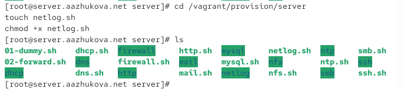

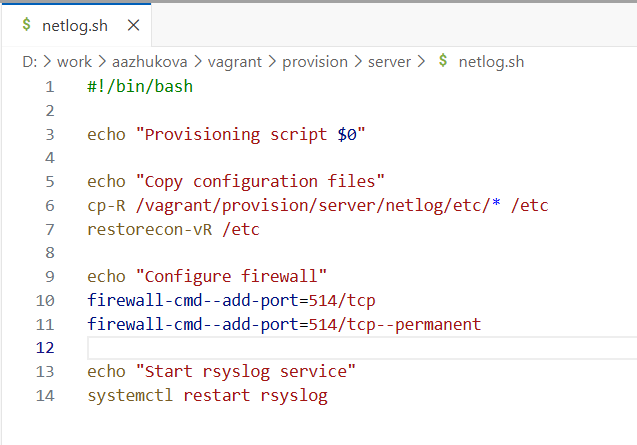

## Создание скрипта настройки для клиента

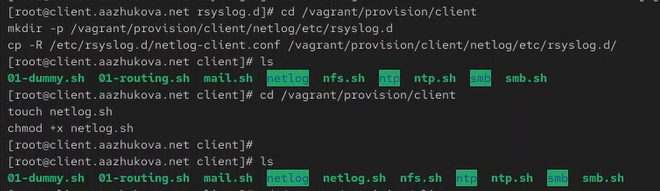

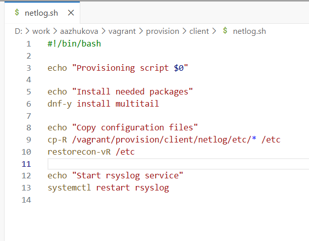

## Интеграция скриптов в Vagrantfile

```ruby
server.vm.provision "server netlog",
  type: "shell",
  preserve_order: true,
  path: "provision/server/netlog.sh"
client.vm.provision "client netlog",
  type: "shell",
  preserve_order: true,
  path: "provision/client/netlog.sh"
```

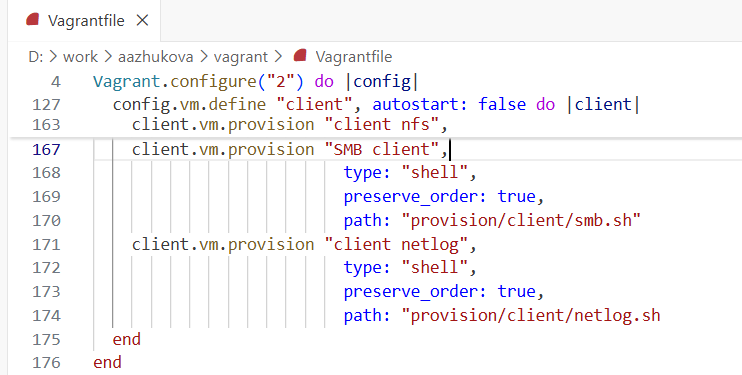

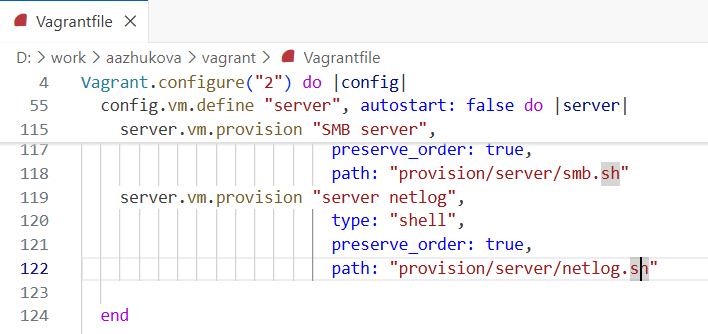

# Результаты

## Подтверждение работы сетевого журналирования

- В логах сервера присутствуют записи от клиента
- Клиент успешно отправляет системные сообщения на сервер
- Все службы работают корректно после настройки

# Выводы

## Итоги проделанной работы

- Получены практические навыки настройки сетевого журналирования
- Сервер успешно настроен для приёма логов по TCP-порту 514
- Клиент корректно перенаправляет системные сообщения на сервер
- Освоены различные методы просмотра журналов (tail, multitail)
- Созданы скрипты для автоматизации настройки через Vagrant

## Преимущества централизованного журналирования

- Упрощение анализа логов с нескольких узлов
- Повышение безопасности хранения лог-сообщений
- Централизованное управление дисковым пространством
- Удобство администрирования и мониторинга

# Итоговый слайд

## Главные достижения работы

- Освоен процесс настройки централизованного журналирования
- Получены практические навыки работы с rsyslog
- Достигнута автоматизация процесса настройки
- Подтверждена работоспособность конфигурации
- Готовность к применению полученных знаний в реальных условиях